# Statistisk databehandling MT5013

## Multivariata och högdimensionel data

## Variabler och observationer

- I kursen har vi enbart tittat på “multivariat data”, \(\mathbf{x}_i=(x_{1,i}, x_{2,i},...,x_{p,i})\):

```r
head(mtcars, n = 3) %>%
  knitr::kable()
```

|  | mpg | cyl | disp | hp | drat | wt | qsec | vs | am | gear | carb |
| --- | --- | --- | --- | --- | --- | --- | --- | --- | --- | --- | --- |
| Mazda RX4 | 21.0 | 6 | 160 | 110 | 3.90 | 2.620 | 16.46 | 0 | 1 | 4 | 4 |
| Mazda RX4 Wag | 21.0 | 6 | 160 | 110 | 3.90 | 2.875 | 17.02 | 0 | 1 | 4 | 4 |
| Datsun 710 | 22.8 | 4 | 108 | 93 | 3.85 | 2.320 | 18.61 | 1 | 1 | 4 | 1 |

## “Högdimensionell” data

- \(\mathbf{x}_i=(x_{1,i}, x_{2,i},...,x_{p,i})\), \(p\) är väldigt stort
- **Vårt mål är att visualisera och beskriva data.**
- Samspel mellan variabler.
- Grupper av “liknande” observationer.

Exempel: Finans, Biologi, Epidemiologi, Ekologi, …

## Försök till visualisationer av högre dimensioner, en massa exempel

## Linjer (Nej)

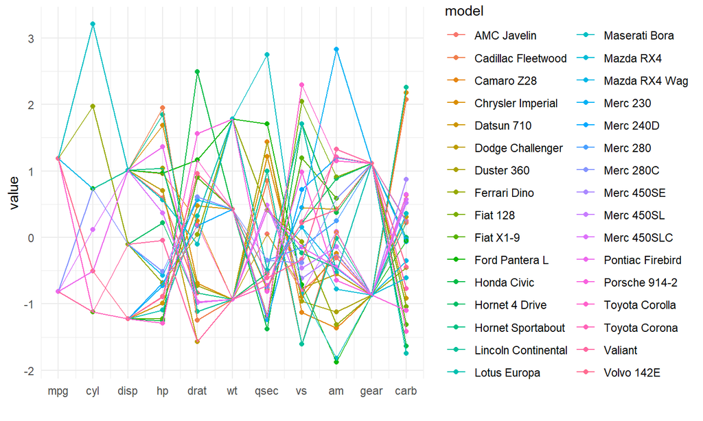

## Linjer (Nja?)

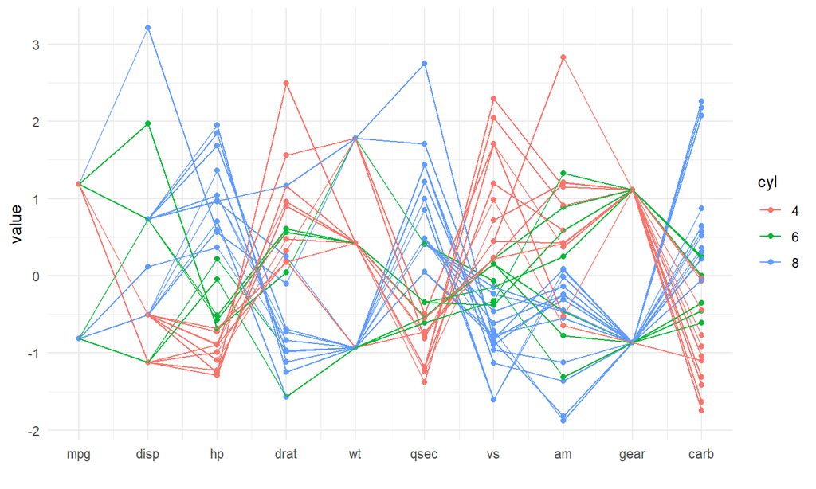

## Glyfer `stars(mtcars)`

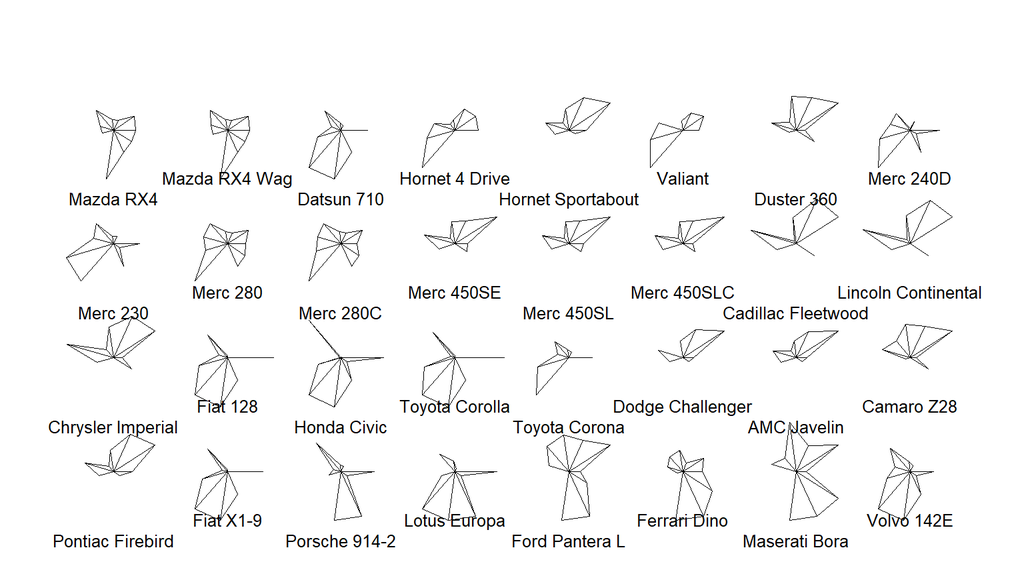

## Chernoff faces

`aplpack::faces(mtcars)`

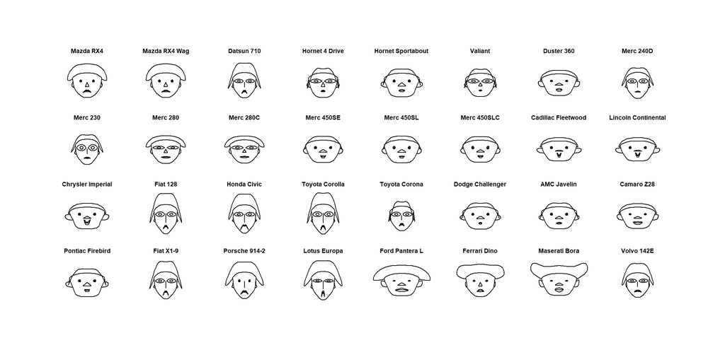

## Heatmap (standardiserade var.)

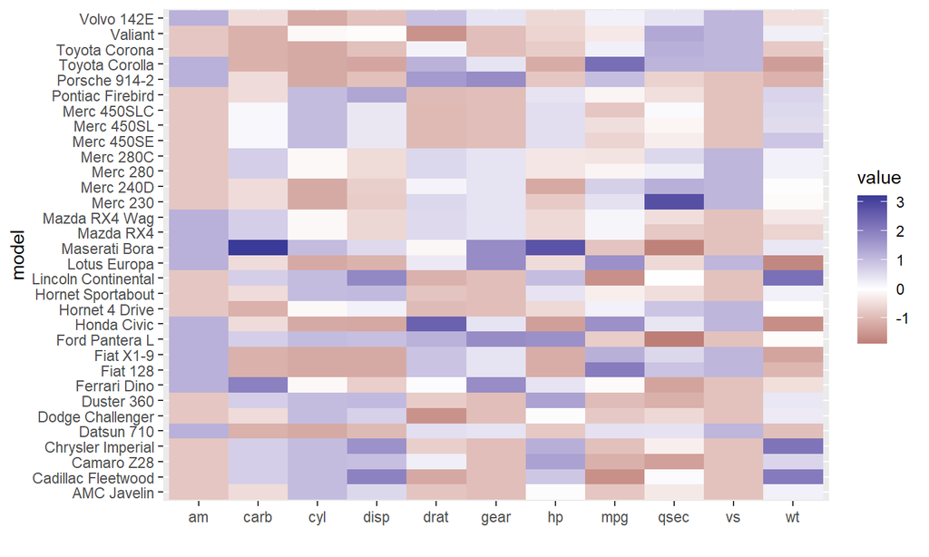

## Samspel `corrplot::corrplot`

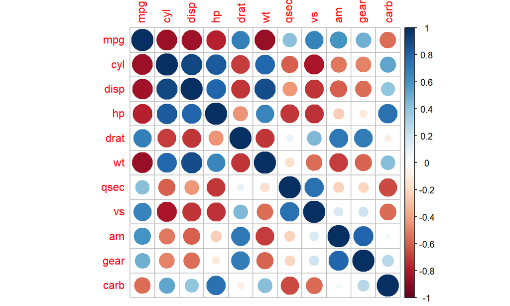

## Samspel `GGally::scatmat(trees)`

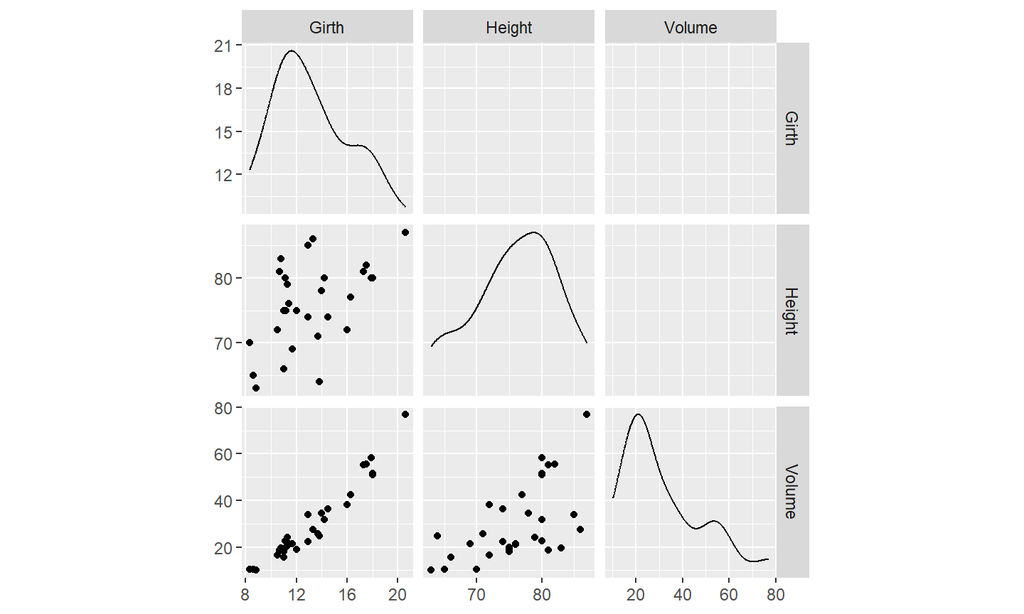

## Samspel `GGally::scatmat(mtcars)` (Nej)

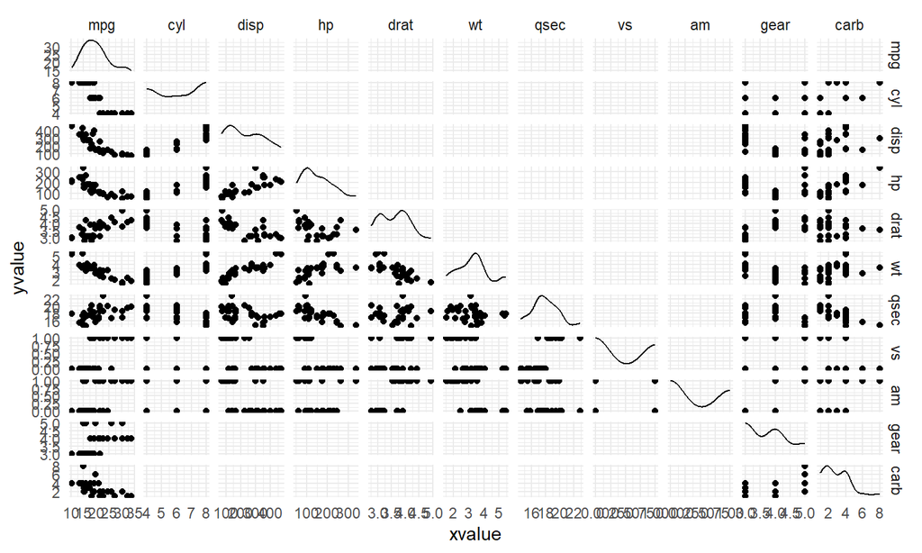

## Samspel `GGally::scatmat(randu)`

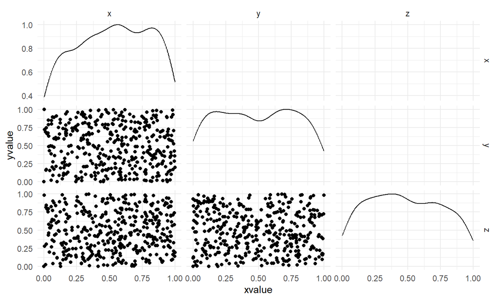

## Samspel `rgl::plot3d(randu)`

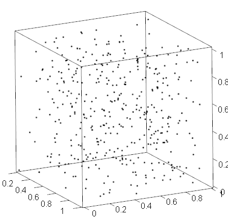

## Samspel `rgl::plot3d(randu)`

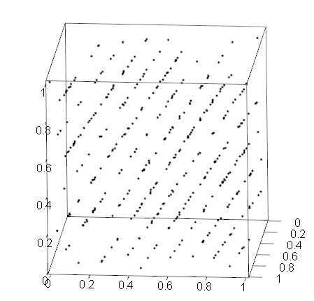

## Singulärvärdesuppdelning

## Singulärvärdesuppdelning

\(X \; (n \times p)\), \(n\) observationer. Antag centrerad. Singulärvärdesuppdelning (SVD) av \(X\)

\[ X = UD V' \]

- \(U (n\times p)\) har ortonormala kolumner (\(U'U = I\))
- \(D := \operatorname{diag}(d_1,\ldots, d_p),\: d_1\geq \ldots \geq d_p\), ofta \(d_p \geq 0\).
- \(V (p\times p)\) har ortonormala kolumner

## Singulärvärdesuppdelning

\[ \begin{align*} X & = UD V' = \sum_{i=1}^p u_id_iv_i'\\ & \approx \sum_{i=1}^q u_id_iv_i' = U_{1:n,1:q}D_{1:q}V_{1:q}, \end{align*} \] för \(q<p\). Vi approximerar datan med \(U_{1:n,1:q}\) som vi kan “enkelt visualisera”

## `scatmat` av `svd(randu)`

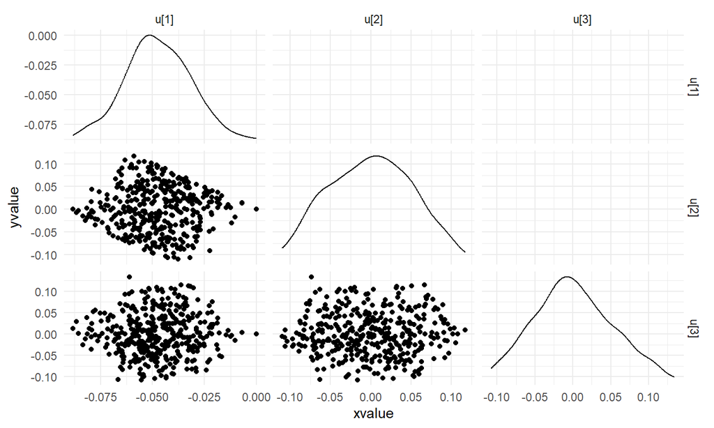

- Testa på `rgl::plot3d` av `svd(randu)`!

## Data `TMD (Kaggle)`

- Rörelse/Ljud android telefoner ([Kaggle data](https://www.kaggle.com/fschwartzer/tmd-dataset-5-seconds-sliding-window/data))
- **Manipulerar datan (väldigt selektivt) för att illustrera SVD så gott som möjligt.**
- p=14, n=5893.

```r
select(df_tmp, target, `sound#mean`, `android.sensor.gyroscope#mean`) %>%
  head(n = 3) %>% knitr::kable()
```

| target | sound#mean | android.sensor.gyroscope#mean |
| --- | --- | --- |
| Still | 0.00000 | 0.0016508 |
| Car | 89.20021 | 0.0363257 |
| Still | 0.00000 | 0.0015246 |

## `TMD` data

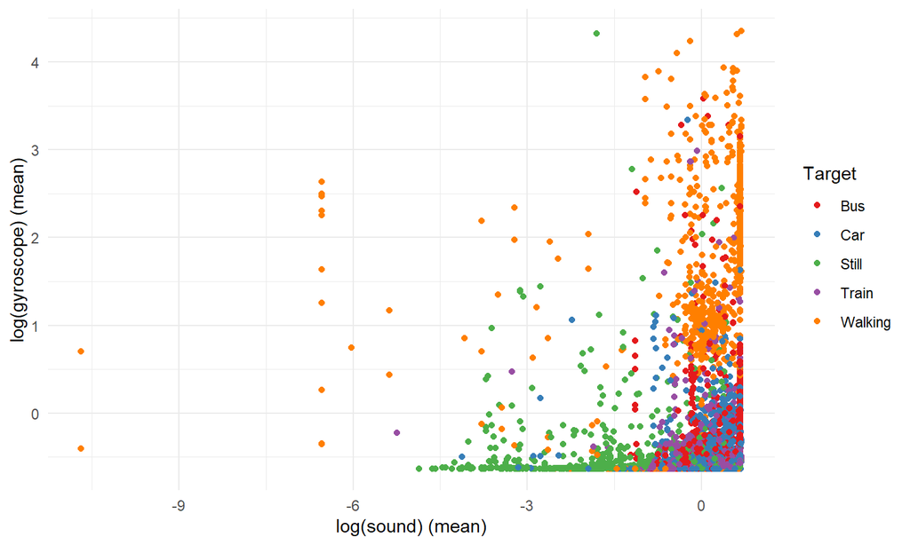

## \(u_1\) och \(u_2\)

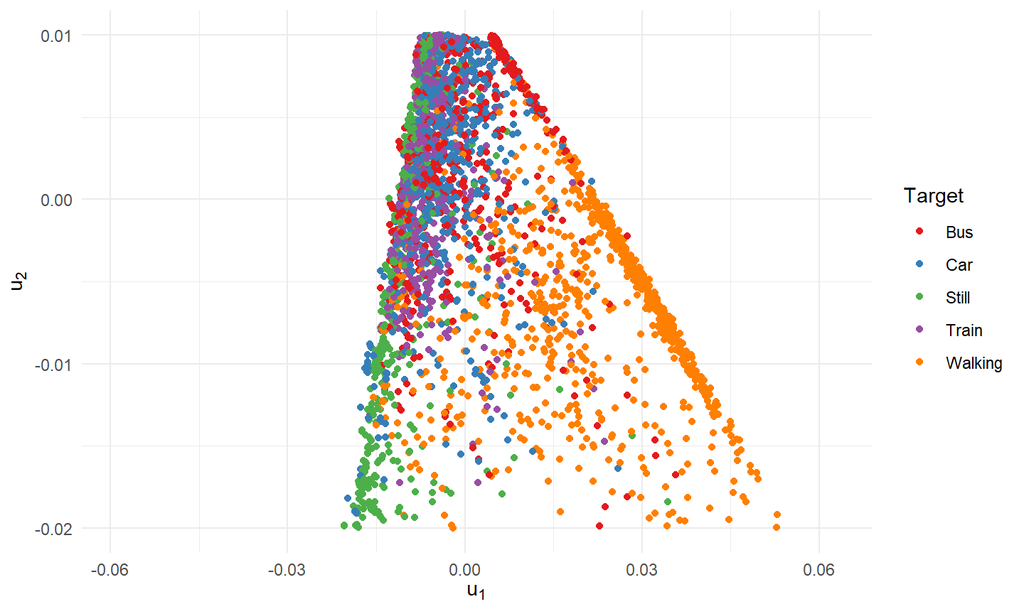

## \(u_4\) och \(u_5\) ser mer ut som brus

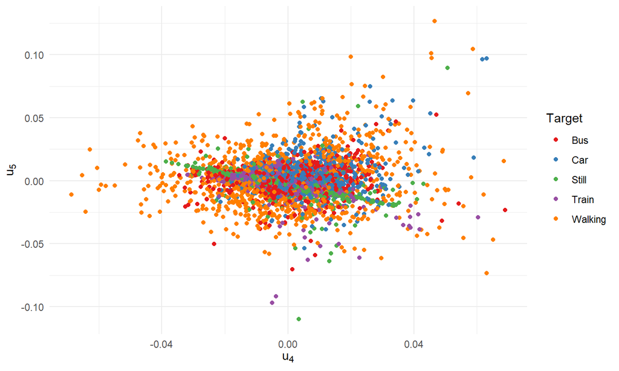

## Återskapa \(X\) med fåtal singulärvärde?

Använd endast de fyra största singulärvärdena, \(\tilde{D}=\operatorname{diag}(d_1,d_2,d_3,d_4,0,...,0)\).

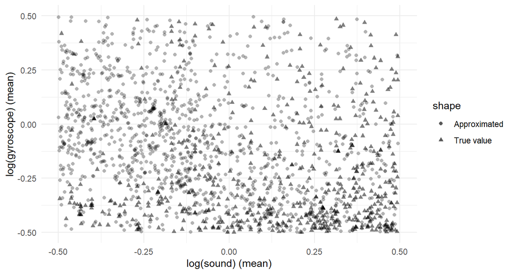

## Principalkomponenter

## Principalkomponenter

- Egenvektorerna till “kovariansmatrisen” (högra egenvektorerna till \(X\)) \[X^TX v_i = \lambda_i v_i\]
- Hur relaterar SVD och principalkomponenter? \[X^TX=(UD V^T)^TUD V^T=V D U^TU D V^T=VD^2V^T\]
- Som tidigare så väljer ofta att visualisera \[X V = U D\] vilket är “roterad data” med en otrogonal bas (ej oberoende)!

## Principalkomponenter

1. \[\max_{v_1} \operatorname{Var}(X\times v_1),\: |v_1|=1\]
2. \[\max_{v_2} \operatorname{Var}(X\times v_2),\: |v_2|=1,\: v_1\perp v_2 \]
3. …

PCA tittar försöker hitta variabler som beskriver variansen!

## Tiokamp

Vi tänker titta på alla poäng-relaterade kolumner, finns i dataframe `scores`. Vi tror att dessa borde korrelera!

```r
library(GDAdata)
scores_ <- select(Decathlon, starts_with("P"), -Polevault)
scores <- mutate_all(scores_, scale)
head(scores_, n=3) %>% knitr::kable()
```

| P100m | Plj | Psp | Phj | P400m | P110h | Ppv | Pdt | Pjt | P1500 |
| --- | --- | --- | --- | --- | --- | --- | --- | --- | --- |
| 938 | 1061 | 773 | 859 | 896 | 911 | 880 | 732 | 757 | 752 |
| 839 | 975 | 870 | 749 | 887 | 878 | 880 | 823 | 863 | 741 |
| 814 | 866 | 841 | 887 | 921 | 939 | 819 | 778 | 884 | 691 |

## Tiokamp

PCA - Bekräfta att matten stämmer:

```r
mat_scores <- as.matrix(scores)
eigen_scores <- eigen(t(mat_scores) %*% mat_scores)
svd_scores <- svd(scores)
all(abs(eigen_scores$values - svd_scores$d^2) < 10^(-7))
```

```
## [1] TRUE
```

- Ger de samma högra egenvektorer?

```r
pca_scores <- stats::prcomp(scores, retx = TRUE)
all(abs(pca_scores$rotation) - abs(eigen_scores$vectors) < 10^(-7))
```

```
## [1] TRUE
```

## `biplot` “överplottad”

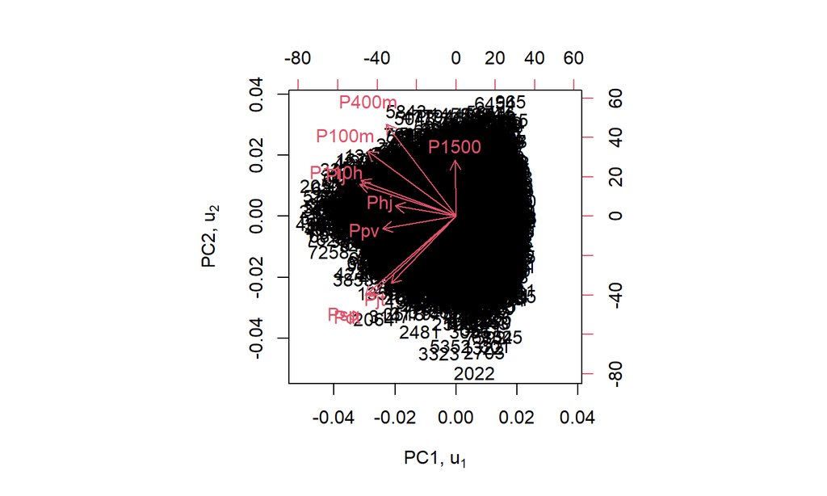

- “PC”/“Principal scores” - enklast tolkat \(U\) från SVD.

## `biplot`

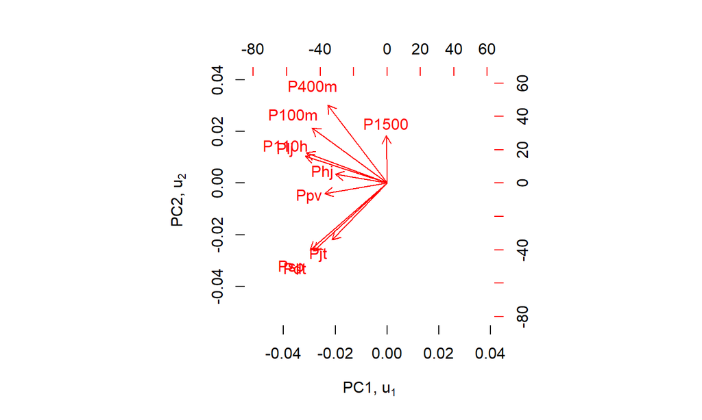

- “Pilar” är element från rotationen \(V\)

## Klusteranalys

## En väldigt övergripande introduktion till klusteranalys

Vi vill hitta kluster av observationer/variabler som liknar varandra

- Om två kolumnerna är “nära” varandra mäter variablerna samma storhet
- Om två rader är nära varandra är observationerna lika
- Vi begränsar oss till euklidiskt avstånd, kräver standardisering (`scale`)

## Hierarkisk linkage

1. Varje observation utgör ett kluster. Beräkna en “avståndsmatris”, distans mellan varje kluster.
2. Slå ihop de två “närmaste” klustren, bestäm ny avståndsmatris.
3. Upprepa steg 2 tills det bara finns ett kluster.

i R `stats::hclust`. Avstånd mellan kluster? `method = Complete, Single, Average`

## Visualisera med dendrogram `scores` (Tiokamp, kolumner)

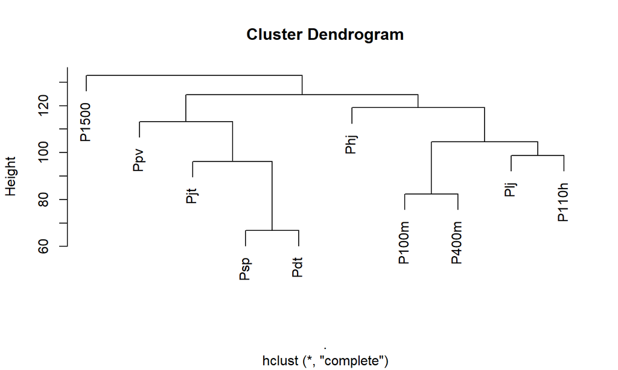

## Visualisera med dendrogram, `mtcars` (rader)

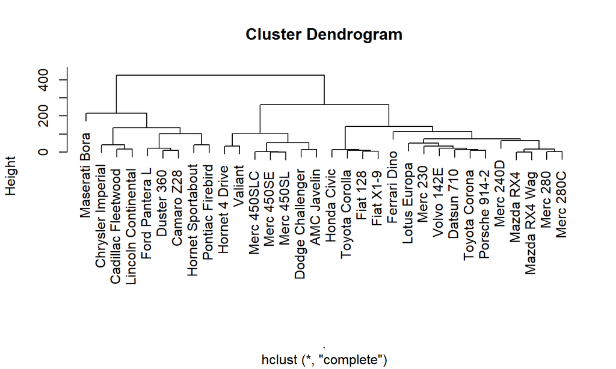

## Visualisera med dendrogram, `mtcars` (rader+labels)

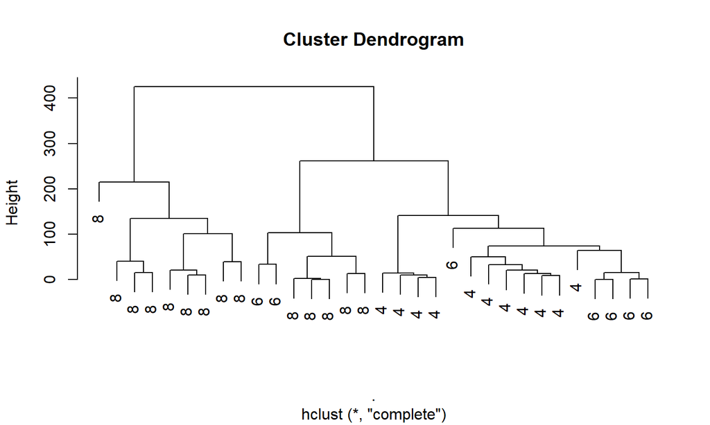

## Heatmap sorterad efter klustring

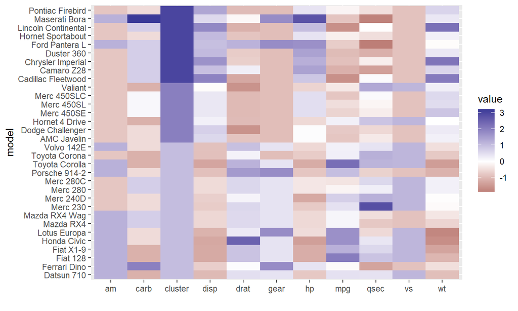

## Sammanfattning

## Högre dimensioner

- Lätt att tolka och visualisera parvisa samband, inte så lätt att beskriva samband i \(p > 2\).
- PCA och SVD är linjära, men hur tolkar vi dessa? ex. \(X\) innehåller ordinala, nominella och kontinuerliga variabler.
- För ickelinjära samband är det ännu svårare. Vad jag vet finns det ingen gyllene hammare…
- Utgå alltid från det ni vill besvara och konstruera figuren därefter.